# Systematic literature review - Analysis

Vincent Bagilet

Columbia University

Léo Zabrocki

Paris School of Economics

2021-01-25

# Purpose of the document

In the present document, we aim to conduct a systematic review of the literature on short term health effects of air pollution. The objective is two-fold:

- Retrieve effect sizes and confidence intervals in order to compute power, type M and type S error in the literature
- Get a sense of the proportion of papers in this literature discussing power and missing data issues.

# Motivation

Our paper and analysis overall partly aims at evaluating whether the literature of short terms health effects of air pollution suffers from power and bias issues. For years, the empirical economic literature has been obsessed with unbiasness. Researchers have developed empirical methods and techniques in a quest to retrieve unbiased estimates. Yet, due to their inherent constraints, these techniques limit the set of settings in which one can retrieve causal and unbiased estimates. They also often tend to focus on limited samples of the data, leading to a reduction in sample size? This can ultimately lead to underpowered studies. As underlined by Gelman and Carlin (2014), a lack of power is often associated with type M and type S error. In a quest for unbiasness, practitioners use methods leading to smaller sample size which can ultimately create bias (type M and type S error). We thus aim at analysing whether the literature of short term health effects of air pollution suffers from power, type M and type S error issues.

In this particular document, we focus mainly on the epidemiology literature. We take advantage of a somehow standardized reporting mechanism to retrieve estimates and confidence intervals from abstracts. This enable us to compute design calculations.

# Power analysis

In this section, we implement robustness tests in order to compute the power, type M and type S error in the studied articles. We look at what would be the power, type M and type S error if the true effect was a fraction of the measured effect. We retrieved estimates and confidence intervals of articles in the literature of interest in another document. Before looking into the power analysis itself, we look at the characteristics of the articles considered.

## Articles characteristics

### Full set of articles

We retrieved the articles using the following query:

‘TITLE((“air pollution” OR “air quality” OR “particulate matter” OR ozone OR “nitrogen dioxide” OR “sulfur dioxide”) AND (“emergency” OR “mortality”) AND NOT (“long term” or “long-term”)) AND (“particulate matter” OR ozone OR “nitrogen dioxide” OR “sulfur dioxide”)’

### Abstracts with effects and confidence intervals

In these articles, we retrieve valid effects and confidence intervals in the following proportions:[^1]

Number of articles for which at least one effect is retrieved (out of those containing the phrase ‘CI’)

| Effect retreived | Number of articles | Proportion |
| --- | --- | --- |
| Yes | 599 | 0.8557143 |
| No | 101 | 0.1442857 |

This corresponds **to 1880 valid effects** and associated confidence intervals.

### Comparison between abstracts with and without detected effects

In this subsection, we investigate whether there are systematic differences between articles displaying an effect that we detected in the abstract and articles that do not display an effect or for which we did not detect the effect.

We first wonder whether there are disparities in publication dates. It might be the case that displaying effects in the abstract was a feature of a given period.

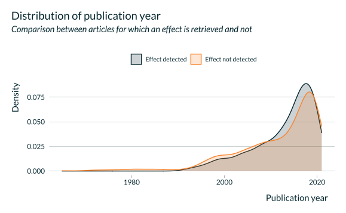

Even though there are slightly more recent (2010-2020) articles for which effects are retrieved, the difference does not seem to be substantial.

We also investigate whether there are differences in the journals in which the articles are published.

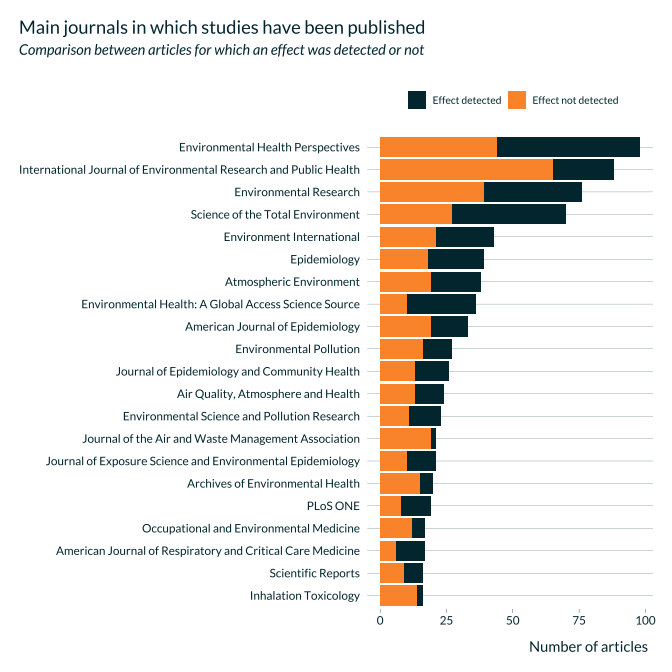

For this analysis to be informative, we would need to cluster the journals into groups (*eg* epidemiology journals, general science journals, etc).

Then, we wonder if the the themes considered in each types of abstracts differ.

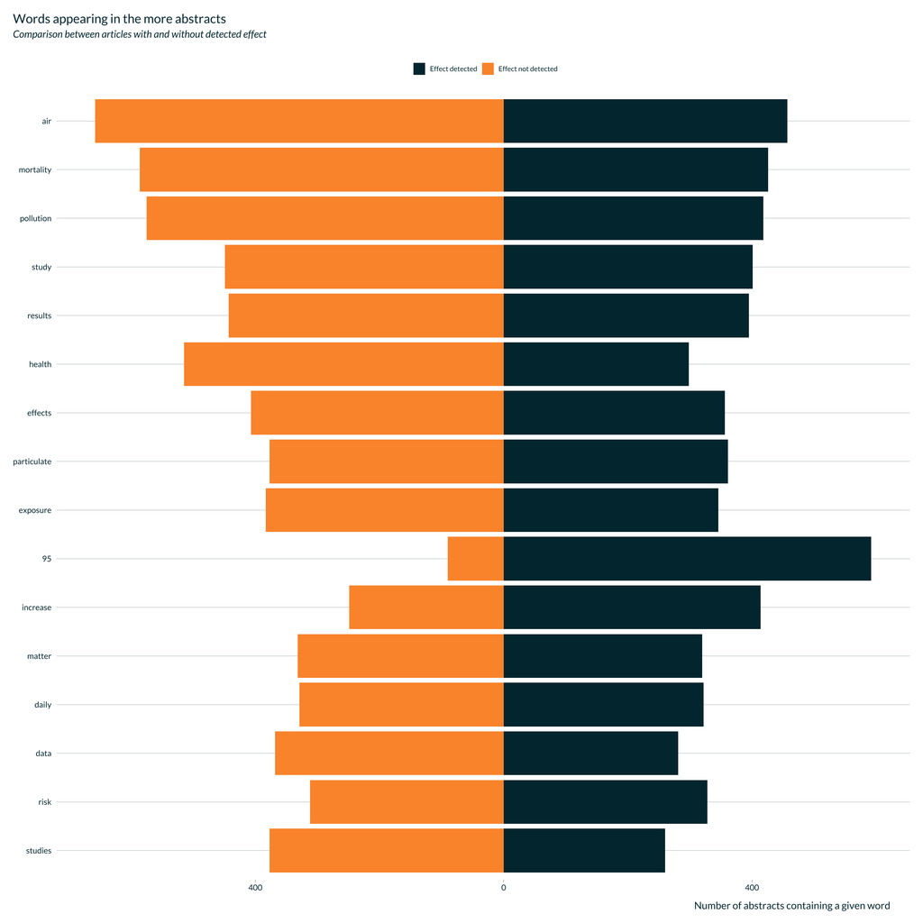

Apart from a few key terms, such as CI, 95 for instance, there are no huge variations in the themes.

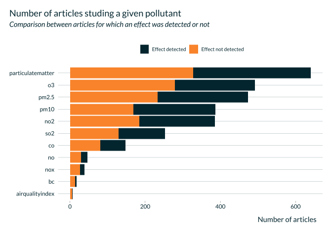

We do not seem to detect effects more for a pollutant than for another. Note that if an article considers several pollutants, it will appear several times in this graph.

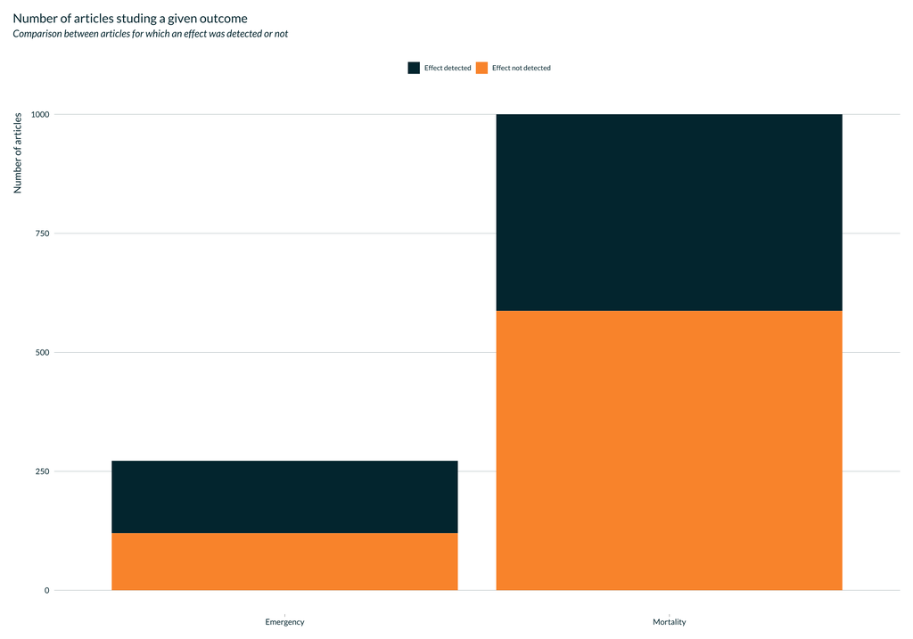

Now that we have quickly compared the articles for which we retrieve an effect an those for which we don’t, we can dig further into the analysis of the estimates retrieved.